# Statistics and Data Analyst

## Internship Study

### Background

How different are statistics and data analyst internships? In general, statistics deal with collecting data and interpreting data to explain questions. Specifically, biostatistics are a sub field of statisticians, who work specifically in the medical and biology fields.

Data analysts often work more with computer programs and data manipulation.  
Both also have strong mathematic bases, and can do similar tasks.

This study looks at statistics versus data analysts and compares their distances from Rexburg and their sizes.

### Procedures

The following key words were typed in the search engine: biostatistics intern and data analyst intern.

“Biostatistics intern” was typed in in the search bar, “United States” typed in the middle box, and “Jobs” default tab was left. Then after searched, the “Filters” option allowed a search for only “internship”. All other filters were left at default. Glassdoor only searched for internships posted within the past month or less.

Only chose internships that included a need for college bachelor or bachelor seeking students, and it was better when the company specified a major in biostatistics, statistics, or a mathematic related field of study, though not required when looking at data analyst intern opportunities.

After going through the search engine of “United States”, further searches for each state where an internship was found yielded more internship opportunities.

The sample size is a bit small due to the requirements and the type of internship searched for during the month of June.

*Factors*

- Distance represents the internship’s location from Rexburg, Idaho.
- Size represents the maxiumum amount of employees hired in the company.

*Types of Interns*

- Stat representing statistic or biostatistic internships.
- Data representing data analysis internships.

## Inquiry 1

Is there a difference between the distance from Rexburg, Idaho of the companies that offer biostatistic internships and data analysis internships?

### Analysis

Comparing Stat and Data to distance, the Wilcoxon Rank Sum Test is used because the distributions are not normal and there is a small sample size ($n < 50$).

$H_0: \text{the distance distributions are stochastically equal}$

Stochastistically, usually an assumed partial order.

The significance level needs to be distributed evenly to all the hypotheses tests, so the original $a=0.05$ will be divided by two to accommodate two tests.

It will be set at

$$\alpha = 0.025$$

### Results

```r
pander(wilcox.test(Distance ~ Intern, data= Intern1, mu=0, alternative= "greater", conf.level= 0.95))
```

Wilcoxon rank sum test with continuity correction: `Distance` by `Intern`

| Test statistic | P value | Alternative hypothesis |
| --- | --- | --- |
| 71 | 0.2439 | greater |

Note there are ties in the data, so the $p-value$ is not fully accurate, but the test is still valid.

From the test, it is interpreted, there is insufficient evidence to conclude that one distance distribution is stochastically greater than the other.

### 5 Number Summary

```r
pander(favstats(Distance ~ Intern, data= Intern1))
```

| Intern | min | Q1 | median | Q3 | max | mean | sd | n | missing |
| --- | --- | --- | --- | --- | --- | --- | --- | --- | --- |
| Data | 258 | 878.8 | 1404 | 2247 | 2441 | 1495 | 751.4 | 12 | 0 |
| Stat | 863 | 920.2 | 1016 | 1188 | 2189 | 1230 | 516.3 | 10 | 0 |

### Graphical Summary

The boxplot is denoted in gray because the test is insignificant.

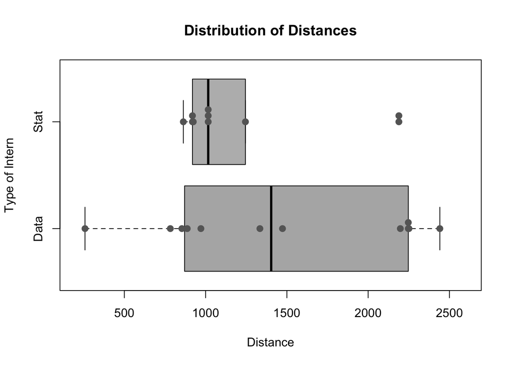

```r
boxplot(Distance ~ Intern, data= Intern1, col=c("gray70", "gray73"), horizontal = TRUE, ylim=c(200,2600), main= "Distribution of Distances", xlab= "Distance", ylab="Type of Intern")
stripchart(Distance ~ Intern, data=Intern1, method="stack", pch=16, col="gray40", cex=1.25, add= TRUE)
```

### Interpretation

The test concludes there the distances away from Rexburg does not differ between a statistic internship and a data analysis internship.

## Inquiry 2

Is there a difference between the size of the company that offers biostatistic internships and data analysis internships?

### Analysis

$H_0: \text{the size distributions are stochastically equal}$

### Results

```r
pander(wilcox.test(Size ~ Intern, data= Intern2, mu=0, alternative= "greater", conf.level= 0.95))
```

Wilcoxon rank sum test with continuity correction: `Size` by `Intern`

| Test statistic | P value | Alternative hypothesis |
| --- | --- | --- |
| 60 | 0.5136 | greater |

Note there are ties in the data, so the $p-value$ is not fully accurate, but the test is still valid.

From the test it is interpreted, there is insufficient evidence to conclude that one distance distribution is stochastically greater than the other.

### 5 Number Summary

The five number summary highlights the meaningful data in this analysis. It’s important to note the means and standard deviations are similar.

```r
pander(favstats(Size ~ Intern, data= Intern2))
```

| Intern | min | Q1 | median | Q3 | max | mean | sd | n | missing |
| --- | --- | --- | --- | --- | --- | --- | --- | --- | --- |
| Data | 200 | 500 | 750 | 10000 | 10000 | 4033 | 4591 | 12 | 0 |
| Stat | 50 | 275 | 5000 | 10000 | 10000 | 5080 | 4622 | 10 | 0 |

### Graphical Summary

The side-by-side boxplot shown below suggests the distributions are fairly evenly spread out. The dots show where the data lies in regards to the boxplot.

The boxplot is denoted in gray because the test is insignificant.

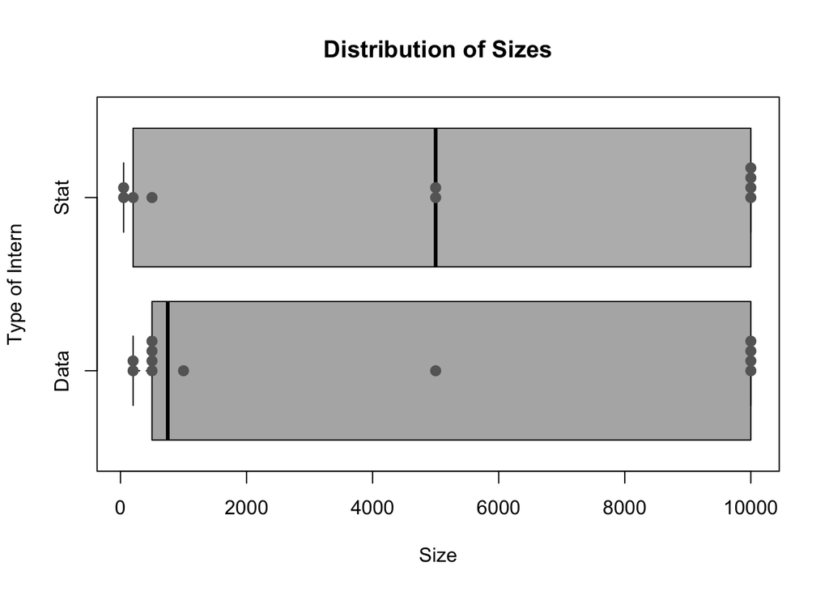

```r
boxplot(Size ~ Intern, data= Intern2, col=c("gray70", "gray73"), horizontal = TRUE, ylim=c(30,10050), main= "Distribution of Sizes", xlab= "Size", ylab="Type of Intern")
stripchart(Size ~ Intern, data=Intern2, method="stack", pch=16, col="gray40", cex=1.25, add= TRUE)
```

### Interpretation

The test concludes there is not a large enough difference in the distributions of stat and data sizes to conclude stat and data analysis are different. The graph supports the p-value by showing a similar spread in the boxplot.

## Conclusion

The results show size and distance does not matter in the selection of the internship. Both are insignificant.

It’s important to note the sample size, time of year, and the cap of one month or less was restricted due to the requirements.

#### Improvements

Improvements could be made to enhace the validity of this study by

- Larger Sample Size
- Better time of the year to perform study, where there are more internship offers
- Expand to other recruitment websites